# Part I - (Flights and performance)

## Bivariate Exploration

### 1. Range of departure delay each carrier endured

This explores the flight data to see the length of departure delays encountered by each carrier, during the months of December 2019 and December 2020. Visualizations are done using box plots.

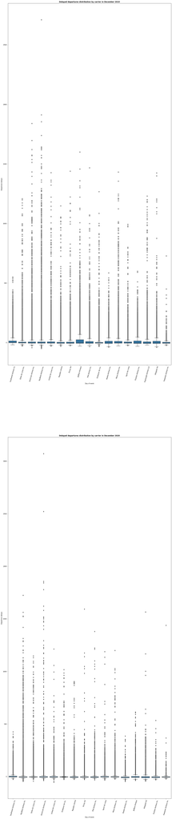

```python
f,ax=plt.subplots(nrows=2,figsize=(20,100))
#Plot December 2019
#Create a variable to store the frequencies of carriers, ordered by the largest occurrences to the smallest
dest_2019 = df_flights_12_2019_new['CARRIER_DESCRIPTION'].value_counts()
#Capture the names of the carriers
city_dest_2019 = dest_2019.index
#Plot carrier vs departure delays
sb.boxplot(data = df_flights_12_2019_new, x = 'CARRIER_DESCRIPTION', y = 'DEP_DELAY'  , color = default_color, order=city_dest_2019, ax=ax[0])
ax[0].set_xlabel('Day of week')
ax[0].set_ylabel('Departure delays')
ax[0].set_title('Delayed departures distribution by carrier in December 2019', fontweight='bold')
ax[0].tick_params(axis="x", rotation=75)

#Plot December 2020
#Create a variable to store the frequencies of the carriers, ordered by the largest occurrences to the smallest
dest_2020 = df_flights_12_2020_new['CARRIER_DESCRIPTION'].value_counts()
#Capture the names of the carriers
city_dest_2020 = dest_2020.index
#Plot carrier vs departure delays
sb.boxplot(data = df_flights_12_2020_new, x = 'CARRIER_DESCRIPTION', y = 'DEP_DELAY', color = default_color, order=city_dest_2020, ax=ax[1])
ax[1].set_xlabel('Day of week')
ax[1].set_ylabel('Departure delays')
ax[1].set_title('Delayed departures distribution by carrier in December 2020', fontweight='bold')
ax[1].tick_params(axis="x", rotation=75)
plt.show()
```

**Observation:** The box plots show that the lower whisker across all the plots were below zero, indicating that there were instances when flights departed earlier than scheduled. Additionally, the plots show that the majority of delays across all carriers were under 100 minutes long, as seen by the highest whisker. However there are many outliers across all carriers, indicating that there were times when delays were excessively long, although there were less frequent than the majority of delays. SkyWest Airlines stands out as the carrier with the largest delay in one instance.

### 2. Range of arrival delays each carrier endured

Here I explore the carriers and generate boxplots to give a visualization of the range of arrival delays encountered, to see the minimum, maximum minutes and any outlier. This covers December 2019 and 2020.

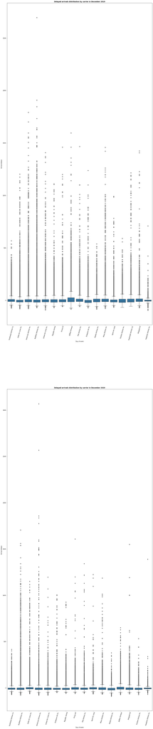

```python
#Box plots for December 2019
f,ax=plt.subplots(nrows=2,figsize=(20,100))
#Create a variable to store the frequencies of carriers names, ordered by the largest occurrences to the smallest
carr_2019 = df_flights_12_2019_new['CARRIER_DESCRIPTION'].value_counts()
#Capture the names of the carriers
city_carr_2019 = carr_2019.index
sb.boxplot(data = df_flights_12_2019_new, x = 'CARRIER_DESCRIPTION', y = 'ARR_DELAY'  , color = default_color, order=city_carr_2019, ax=ax[0])
ax[0].set_xlabel('Day of week')
ax[0].set_ylabel('Arrival delays')
ax[0].set_title('Delayed arrivals distribution by carrier in December 2019', fontweight='bold')
ax[0].tick_params(axis="x", rotation=75)

#Plot December 2020
#Create a variable to store the frequencies of carriers names, ordered by the largest occurrences to the smallest
carr_2020 = df_flights_12_2020_new['CARRIER_DESCRIPTION'].value_counts()
#Capture the names of the carriers
city_carr_2020 = carr_2020.index
sb.boxplot(data = df_flights_12_2020_new, x = 'CARRIER_DESCRIPTION', y = 'ARR_DELAY', color = default_color, order=city_carr_2020, ax=ax[1])
ax[1].set_xlabel('Day of week')
ax[1].set_ylabel('Arrival delays')
ax[1].set_title('Delayed arrivals distribution by carrier in December 2020', fontweight='bold')
ax[1].tick_params(axis="x", rotation=75)
plt.show()
```

**Observation:** Like the box plots for the carrier vs departure delays above, the carrier vs arrival plots show that the lower whiskers across all the plots were below zero, indicating that there were instances when flights arrived earlier than scheduled. Additionally, the plots show that the majority of delays across all carriers were way under 100 minutes long, as seen by the highest whisker. However there are many outliers across all carriers, indicating that there were times when delays were excessively long, although there were less frequent than the majority of delays. SkyWest Airlines and American Airlines stand out as the carrier with the largest delay in December 2019 and 2020.